# Project - Practical Machine Learning

David Berkowitz

March 3, 2015

```r
library (caret, quietly=TRUE)
library (randomForest, quietly=TRUE)
set.seed (123)
```

### Read in the data

```
## [1] "RDS exists, reading it"
## [1] "."
```

### Feature selection (reduce the number of columns)

Many of the columns are statistical calculations (min_, max_, avg_, stddev_, var_, skewness_, kurtosis_) on the raw data measurements. I chose to build my classifier only on raw data columns: gyro_, accel_ and magnet_.

```r
names = names (data.raw) # get the list of column names

gyros = grep ("^gyros", names)
accel = grep ("^accel", names)
magnet = grep ("^magnet", names)
class = grep ("^classe", names) # add the activity column
user = grep ("^user", names) # add the user name column

data = data.raw [, c(gyros, accel, magnet, class, user)] # only include wanted columns
data = na.omit (data) # omit NA values which are not appreciated by later functions
```

### Partition the data

```r
set.seed (12345)
dp = createDataPartition (y = data$classe, p = 0.6, list=FALSE)
myTraining = data [dp,] # training set has random 60%
myTesting = data [-dp, ] # testing set has the remaining 40%

a = nrow (data) ; b = nrow (myTraining) ; c = nrow (myTesting)
check = a - b - c
cbind (a, b, c, check) # check should equal 0
```

```
##          a     b    c check
## [1,] 19622 11776 7846     0
```

### Create the classifier based on my training set

```r
rf = randomForest (classe ~ ., data=myTraining); rf
```

```
##
## Call:
##  randomForest(formula = classe ~ ., data = myTraining)
##                Type of random forest: classification
##                      Number of trees: 500
## No. of variables tried at each split: 6
##
##         OOB estimate of  error rate: 1.55%
## Confusion matrix:
##      A    B    C    D    E class.error
## A 3341    2    1    3    1 0.002090800
## B   34 2223   21    0    1 0.024572181
## C    2   24 2026    2    0 0.013631938
## D    8    3   58 1858    3 0.037305699
## E    0    4    5   10 2146 0.008775982
```

### Evaluate the classifier based on my testing set

```r
predictions = predict (rf, myTesting)
confusionMatrix (predictions, myTesting$classe)
```

```
## Confusion Matrix and Statistics
##
##           Reference
## Prediction    A    B    C    D    E
##          A 2226   22    2    5    2
##          B    2 1484   18    0    0
##          C    0   12 1345   40    7
##          D    4    0    2 1237    6
##          E    0    0    1    4 1427
##
## Overall Statistics
##
##                Accuracy : 0.9838
##                  95% CI : (0.9808, 0.9865)
##     No Information Rate : 0.2845
##     P-Value [Acc > NIR] : < 2.2e-16
##
##                   Kappa : 0.9795
##  Mcnemar's Test P-Value : NA
##
## Statistics by Class:
##
##                      Class: A Class: B Class: C Class: D Class: E
## Sensitivity            0.9973   0.9776   0.9832   0.9619   0.9896
## Specificity            0.9945   0.9968   0.9909   0.9982   0.9992
## Pos Pred Value         0.9863   0.9867   0.9580   0.9904   0.9965
## Neg Pred Value         0.9989   0.9946   0.9964   0.9926   0.9977
## Prevalence             0.2845   0.1935   0.1744   0.1639   0.1838
## Detection Rate         0.2837   0.1891   0.1714   0.1577   0.1819
## Detection Prevalence   0.2877   0.1917   0.1789   0.1592   0.1825
## Balanced Accuracy      0.9959   0.9872   0.9870   0.9800   0.9944
```

This simple predictor does quite well with 98.38% accuracy, which is in line with the OOB estimated error rate of 1.55%.

### Predict based on the real testing set

```r
testingData = read.csv ("pml-testing.csv")
testingData = testingData [, c(gyros, accel, magnet, class, user)] # same dataset filtering as before
testingData = na.omit (testingData)

predictions = predict (rf, testingData); predictions
```

```
##  1  2  3  4  5  6  7  8  9 10 11 12 13 14 15 16 17 18 19 20
##  B  A  B  A  A  E  D  B  A  A  B  C  B  A  E  E  A  B  B  B
## Levels: A B C D E
```

This “simple” classifier was sufficient to correctly predict all 20 values for the course project submission.

### Cross Validation

```r
table (data$user_name, data$classe)
```

```
##
##               A    B    C    D    E
##   adelmo   1165  776  750  515  686
##   carlitos  834  690  493  486  609
##   charles   899  745  539  642  711
##   eurico    865  592  489  582  542
##   jeremy   1177  489  652  522  562
##   pedro     640  505  499  469  497
```

```r
#ggplot (data, aes (x=classe)) + geom_bar() + facet_wrap (~ user_name)
```

There appear to be sufficient data points for each activity for each user. I will cross validate by user_name.

```r
crossValidate = function (name)
  {
  testingRowNumbers = training = testing = NULL
  a = b = c = check = NULL
  rf = cm = NULL

  testingRowNumbers = grep (name, data$user_name)
  training = data [-testingRowNumbers,]
  testing = data [testingRowNumbers,]

  a = nrow (data) ; b = nrow (training) ; c = nrow (testing); check = a - b - c
  cbind (a, b, c, check) # check should equal 0

  rf = randomForest (classe ~ ., data=training)
  predictions = predict (rf, testing)
  cm = confusionMatrix (predictions, testing$classe)
  cat (name, "accuracy= ", cm$overall ["Accuracy"], "\n")
  return (rf);
  }
```

```r
rf = crossValidate ("adelmo"); rf
```

```
## adelmo accuracy=  0.2834018
```

```
##
## Call:
##  randomForest(formula = classe ~ ., data = training)
##                Type of random forest: classification
##                      Number of trees: 500
## No. of variables tried at each split: 6
##
##         OOB estimate of  error rate: 0.83%
## Confusion matrix:
##      A    B    C    D    E class.error
## A 4409    1    0    4    1 0.001359003
## B   24 2977   20    0    0 0.014564714
## C    3   14 2655    0    0 0.006362275
## D    4    0   46 2649    2 0.019252129
## E    0    2    2    7 2910 0.003765834
```

```r
rf = crossValidate ("carlitos"); rf
```

```
## carlitos accuracy=  0.5780848
```

```
##
## Call:
##  randomForest(formula = classe ~ ., data = training)
##                Type of random forest: classification
##                      Number of trees: 500
## No. of variables tried at each split: 6
##
##         OOB estimate of  error rate: 0.79%
## Confusion matrix:
##      A    B    C    D    E class.error
## A 4741    2    0    2    1 0.001053519
## B   14 3079   13    1    0 0.009011909
## C    2   25 2901    1    0 0.009559577
## D    5    0   54 2667    4 0.023076923
## E    0    1    0    5 2992 0.002001334
```

```r
rf = crossValidate ("charles"); rf
```

```
## charles accuracy=  0.5616516
```

```
##
## Call:
##  randomForest(formula = classe ~ ., data = training)
##                Type of random forest: classification
##                      Number of trees: 500
## No. of variables tried at each split: 6
##
##         OOB estimate of  error rate: 0.75%
## Confusion matrix:
##      A    B    C    D    E class.error
## A 4673    2    0    5    1 0.001709037
## B   18 3023   11    0    0 0.009501966
## C    2   20 2861    0    0 0.007630940
## D    5    0   46 2521    2 0.020590521
## E    0    1    2    6 2887 0.003107735
```

```r
rf = crossValidate ("eurico"); rf
```

```
## eurico accuracy=  0.1765472
```

```
##
## Call:
##  randomForest(formula = classe ~ ., data = training)
##                Type of random forest: classification
##                      Number of trees: 500
## No. of variables tried at each split: 6
##
##         OOB estimate of  error rate: 0.9%
## Confusion matrix:
##      A    B    C    D    E class.error
## A 4710    1    0    4    0 0.001060445
## B   21 3166   18    0    0 0.012168487
## C    3   25 2905    0    0 0.009546539
## D    3    0   61 2567    3 0.025436598
## E    0    0    3    7 3055 0.003262643
```

```r
rf = crossValidate ("jeremy"); rf
```

```
## jeremy accuracy=  0.5684891
```

```
##
## Call:
##  randomForest(formula = classe ~ ., data = training)
##                Type of random forest: classification
##                      Number of trees: 500
## No. of variables tried at each split: 6
##
##         OOB estimate of  error rate: 0.86%
## Confusion matrix:
##      A    B    C    D    E class.error
## A 4392    2    3    5    1 0.002498297
## B   24 3264   20    0    0 0.013301088
## C    2   20 2747    1    0 0.008303249
## D    4    0   50 2636    4 0.021529324
## E    0    1    0    3 3041 0.001313629
```

```r
rf = crossValidate ("pedro"); rf
```

```
## pedro accuracy=  0.1938697
```

```
##
## Call:
##  randomForest(formula = classe ~ ., data = training)
##                Type of random forest: classification
##                      Number of trees: 500
## No. of variables tried at each split: 6
##
##         OOB estimate of  error rate: 0.81%
## Confusion matrix:
##      A    B    C    D    E class.error
## A 4935    2    0    2    1 0.001012146
## B   18 3252   21    1    0 0.012150668
## C    0   19 2904    0    0 0.006500171
## D    1    1   59 2682    4 0.023662177
## E    0    1    2    6 3101 0.002893891
```

### Results

```r
cbind (names, oobErrorRates, accuracy)
```

[output not shown]

```r
mean (oobErrorRates) # average expected error rate (percentage)
```

[output not shown]

```r
mean (accuracy) # average measured accuracy
```

[output not shown]

# Further Investigations

After the later video lectures I wanted to start over and apply some of the techniques discussed. Here are the results.

### Read in the data set

```r
setwd ("/Users/davidberkowitz/Projects/coursera/Practical Machine Learning")

data = read.csv ("pml-training.csv",
                        header=TRUE,
                        as.is = TRUE,
                        stringsAsFactors = FALSE,
                        #sep=',',
                        )
dim (data)
```

```
## [1] 19622   160
```

```r
summary (data)
```

[output not shown]

[output cut: 321 more lines]

[output not shown]

There are 160 columns in the raw data set.

### Remove columns with NAs

```r
NAindex = apply (data, 2, function(x) {sum(is.na(x))})
NAindex
```

[output not shown]

[output cut: 53 more lines]

[output not shown]

```r
data = data [,which (NAindex == 0)]

dim (data)
```

```
## [1] 19622    93
```

```r
summary (data)
```

[output not shown]

[output cut: 141 more lines]

[output not shown]

Number of columns reduced from 160 to 93.

### Preprocess the numeric columns. Preserve the outcome column.

```r
c = data$classe # save

v = which (lapply (data, class) %in% "numeric") # numerica columns only
v
```

```
##  [1]  8  9 10 21 22 23 30 31 32 34 35 36 49 50 51 62 63 64 70 71 72 73 84
## [24] 85 86 91 92
```

```r
ppo = preProcess (data [,v], method=c ('knnImpute', 'center', 'scale'))
data <- predict (ppo, data [,v])

data$classe = as.factor (c) # restore

dim (data)
```

```
## [1] 19622    28
```

```r
summary (data)
```

```
##    roll_belt         pitch_belt          yaw_belt         gyros_belt_x
##  Min.   :-1.4870   Min.   :-2.51016   Min.   :-1.77317   Min.   :-4.9892
##  1st Qu.:-1.0089   1st Qu.: 0.06508   1st Qu.:-0.80987   1st Qu.:-0.1177
##  Median : 0.7744   Median : 0.22257   Median :-0.01886   Median : 0.1717
##  Mean   : 0.0000   Mean   : 0.00000   Mean   : 0.00000   Mean   : 0.0000
##  3rd Qu.: 0.9337   3rd Qu.: 0.65297   3rd Qu.: 0.25322   3rd Qu.: 0.5575
##  Max.   : 1.5553   Max.   : 2.68418   Max.   : 1.99808   Max.   :10.7346
##   gyros_belt_y      gyros_belt_z        roll_arm         pitch_arm
##  Min.   :-8.6864   Min.   :-5.5091   Min.   :-2.7195   Min.   :-2.7439
##  1st Qu.:-0.5060   1st Qu.:-0.2878   1st Qu.:-0.6819   1st Qu.:-0.6938
##  Median :-0.2504   Median : 0.1265   Median :-0.2451   Median : 0.1503
##  Mean   : 0.0000   Mean   : 0.0000   Mean   : 0.0000   Mean   : 0.0000
##  3rd Qu.: 0.9000   3rd Qu.: 0.4581   3rd Qu.: 0.8175   3rd Qu.: 0.5153
##  Max.   : 7.6744   Max.   : 7.2540   Max.   : 2.2293   Max.   : 3.0347
##     yaw_arm          gyros_arm_x        gyros_arm_y
##  Min.   :-2.51363   Min.   :-3.21669   Min.   :-3.73849
##  1st Qu.:-0.59528   1st Qu.:-0.68859   1st Qu.:-0.63768
##  Median : 0.00867   Median : 0.01867   Median : 0.02006
##  Mean   : 0.00000   Mean   : 0.00000   Mean   : 0.00000
##  3rd Qu.: 0.65151   3rd Qu.: 0.76607   3rd Qu.: 0.46639
##  Max.   : 2.53097   Max.   : 2.42137   Max.   : 3.63767
##   gyros_arm_z       roll_dumbbell     pitch_dumbbell     yaw_dumbbell
##  Min.   :-4.69925   Min.   :-2.5390   Min.   :-3.7524   Min.   :-1.84865
##  1st Qu.:-0.61370   1st Qu.:-0.6054   1st Qu.:-0.8139   1st Qu.:-0.96124
##  Median :-0.07137   Median : 0.3479   Median :-0.2751   Median :-0.06057
##  Mean   : 0.00000   Mean   : 0.0000   Mean   : 0.0000   Mean   : 0.00000
##  3rd Qu.: 0.81444   3rd Qu.: 0.6259   3rd Qu.: 0.7644   3rd Qu.: 0.94488
##  Max.   : 4.97230   Max.   : 1.8547   Max.   : 4.3300   Max.   : 1.85753
##  gyros_dumbbell_x     gyros_dumbbell_y   gyros_dumbbell_z
##  Min.   :-135.33567   Min.   :-3.51818   Min.   : -0.98444
##  1st Qu.:  -0.12667   1st Qu.:-0.30502   1st Qu.: -0.07916
##  Median :  -0.02061   Median :-0.02632   Median : -0.00044
##  Mean   :   0.00000   Mean   : 0.00000   Mean   :  0.00000
##  3rd Qu.:   0.12523   3rd Qu.: 0.26876   3rd Qu.:  0.06953
##  Max.   :   1.36483   Max.   :85.17175   Max.   :138.69025
##  magnet_dumbbell_z  roll_forearm     pitch_forearm       yaw_forearm
##  Min.   :-2.2010   Min.   :-1.9792   Min.   :-2.95628   Min.   :-1.9299
##  1st Qu.:-0.6506   1st Qu.:-0.3199   1st Qu.:-0.38038   1st Qu.:-0.8507
##  Median :-0.2362   Median :-0.1122   Median :-0.05209   Median :-0.1861
##  Mean   : 0.0000   Mean   : 0.0000   Mean   : 0.00000   Mean   : 0.0000
##  3rd Qu.: 0.3497   3rd Qu.: 0.9828   3rd Qu.: 0.62866   3rd Qu.: 0.8796
##  Max.   : 2.9004   Max.   : 1.3530   Max.   : 2.81018   Max.   : 1.5578
##  gyros_forearm_x    gyros_forearm_y     gyros_forearm_z
##  Min.   :-34.1618   Min.   : -2.28823   Min.   : -4.69725
##  1st Qu.: -0.5827   1st Qu.: -0.49510   1st Qu.: -0.18880
##  Median : -0.1664   Median : -0.01457   Median : -0.04061
##  Mean   :  0.0000   Mean   :  0.00000   Mean   :  0.00000
##  3rd Qu.:  0.6199   3rd Qu.:  0.49821   3rd Qu.:  0.19308
##  Max.   :  5.8772   Max.   :100.27489   Max.   :131.57654
##  magnet_forearm_y  magnet_forearm_z  classe
##  Min.   :-2.5053   Min.   :-3.7009   A:5580
##  1st Qu.:-0.7423   1st Qu.:-0.5487   B:3797
##  Median : 0.4140   Median : 0.3179   C:3422
##  Mean   : 0.0000   Mean   : 0.0000   D:3216
##  3rd Qu.: 0.7006   3rd Qu.: 0.7024   E:3607
##  Max.   : 2.1593   Max.   : 1.8859
```

```r
str (data)
```

```
## 'data.frame':    19622 obs. of  28 variables:
##  $ roll_belt        : num  -1 -1 -1 -1 -1 ...
##  $ pitch_belt       : num  0.347 0.347 0.347 0.347 0.347 ...
##  $ yaw_belt         : num  -0.874 -0.874 -0.874 -0.874 -0.874 ...
##  $ gyros_belt_x     : num  0.027 0.123 0.027 0.123 0.123 ...
##  $ gyros_belt_y     : num  -0.506 -0.506 -0.506 -0.506 -0.25 ...
##  $ gyros_belt_z     : num  0.458 0.458 0.458 0.417 0.458 ...
##  $ roll_arm         : num  -2 -2 -2 -2 -2 ...
##  $ pitch_arm        : num  0.884 0.884 0.884 0.871 0.871 ...
##  $ yaw_arm          : num  -2.25 -2.25 -2.25 -2.25 -2.25 ...
##  $ gyros_arm_x      : num  -0.0215 -0.0114 -0.0114 -0.0114 -0.0215 ...
##  $ gyros_arm_y      : num  0.302 0.278 0.278 0.267 0.267 ...
##  $ gyros_arm_z      : num  -0.523 -0.523 -0.523 -0.451 -0.487 ...
##  $ roll_dumbbell    : num  -0.154 -0.153 -0.157 -0.149 -0.15 ...
##  $ pitch_dumbbell   : num  -1.61 -1.62 -1.61 -1.61 -1.61 ...
##  $ yaw_dumbbell     : num  -1.05 -1.05 -1.05 -1.05 -1.05 ...
##  $ gyros_dumbbell_x : num  -0.107 -0.107 -0.107 -0.107 -0.107 ...
##  $ gyros_dumbbell_y : num  -0.108 -0.108 -0.108 -0.108 -0.108 ...
##  $ gyros_dumbbell_z : num  0.0564 0.0564 0.0564 0.0477 0.0564 ...
##  $ magnet_dumbbell_z: num  -0.793 -0.786 -0.779 -0.758 -0.815 ...
##  $ roll_forearm     : num  -0.0502 -0.0512 -0.0512 -0.053 -0.0539 ...
##  $ pitch_forearm    : num  -2.65 -2.65 -2.65 -2.65 -2.65 ...
##  $ yaw_forearm      : num  -1.67 -1.67 -1.66 -1.66 -1.66 ...
##  $ gyros_forearm_x  : num  -0.197 -0.213 -0.197 -0.213 -0.213 ...
##  $ gyros_forearm_y  : num  -0.0242 -0.0242 -0.0307 -0.0307 -0.0242 ...
##  $ gyros_forearm_z  : num  -0.0976 -0.0976 -0.0862 -0.0862 -0.0976 ...
##  $ magnet_forearm_y : num  0.538 0.551 0.546 0.546 0.54 ...
##  $ magnet_forearm_z : num  0.223 0.215 0.204 0.204 0.215 ...
##  $ classe           : Factor w/ 5 levels "A","B","C","D",..: 1 1 1 1 1 1 1 1 1 1 ...
```

### Remove columns with near zero variance

```r
nzv <- nearZeroVar (data, saveMetrics=TRUE)
nzv
```

```
##                   freqRatio percentUnique zeroVar   nzv
## roll_belt          1.101904     6.7781062   FALSE FALSE
## pitch_belt         1.036082     9.3772296   FALSE FALSE
## yaw_belt           1.058480     9.9734991   FALSE FALSE
## gyros_belt_x       1.058651     0.7134849   FALSE FALSE
## gyros_belt_y       1.144000     0.3516461   FALSE FALSE
## gyros_belt_z       1.066214     0.8612782   FALSE FALSE
## roll_arm          52.338462    13.5256345   FALSE FALSE
## pitch_arm         87.256410    15.7323412   FALSE FALSE
## yaw_arm           33.029126    14.6570176   FALSE FALSE
## gyros_arm_x        1.015504     3.2769341   FALSE FALSE
## gyros_arm_y        1.454369     1.9162165   FALSE FALSE
## gyros_arm_z        1.110687     1.2638875   FALSE FALSE
## roll_dumbbell      1.022388    84.2065029   FALSE FALSE
## pitch_dumbbell     2.277372    81.6685353   FALSE FALSE
## yaw_dumbbell       1.132231    83.4828254   FALSE FALSE
## gyros_dumbbell_x   1.003268     1.2282132   FALSE FALSE
## gyros_dumbbell_y   1.264957     1.4167771   FALSE FALSE
## gyros_dumbbell_z   1.060100     1.0498420   FALSE FALSE
## magnet_dumbbell_z  1.020833     3.4451126   FALSE FALSE
## roll_forearm      11.589286    11.0895933   FALSE FALSE
## pitch_forearm     65.983051    14.8557741   FALSE FALSE
## yaw_forearm       15.322835    10.1467740   FALSE FALSE
## gyros_forearm_x    1.059273     1.5187035   FALSE FALSE
## gyros_forearm_y    1.036554     3.7763735   FALSE FALSE
## gyros_forearm_z    1.122917     1.5645704   FALSE FALSE
## magnet_forearm_y   1.246914     9.5403119   FALSE FALSE
## magnet_forearm_z   1.000000     8.5771073   FALSE FALSE
## classe             1.469581     0.0254816   FALSE FALSE
```

```r
data = data [,nzv$nzv==FALSE]

dim (data)
```

```
## [1] 19622    28
```

```r
summary (data)
```

```
##    roll_belt         pitch_belt          yaw_belt         gyros_belt_x
##  Min.   :-1.4870   Min.   :-2.51016   Min.   :-1.77317   Min.   :-4.9892
##  1st Qu.:-1.0089   1st Qu.: 0.06508   1st Qu.:-0.80987   1st Qu.:-0.1177
##  Median : 0.7744   Median : 0.22257   Median :-0.01886   Median : 0.1717
##  Mean   : 0.0000   Mean   : 0.00000   Mean   : 0.00000   Mean   : 0.0000
##  3rd Qu.: 0.9337   3rd Qu.: 0.65297   3rd Qu.: 0.25322   3rd Qu.: 0.5575
##  Max.   : 1.5553   Max.   : 2.68418   Max.   : 1.99808   Max.   :10.7346
##   gyros_belt_y      gyros_belt_z        roll_arm         pitch_arm
##  Min.   :-8.6864   Min.   :-5.5091   Min.   :-2.7195   Min.   :-2.7439
##  1st Qu.:-0.5060   1st Qu.:-0.2878   1st Qu.:-0.6819   1st Qu.:-0.6938
##  Median :-0.2504   Median : 0.1265   Median :-0.2451   Median : 0.1503
##  Mean   : 0.0000   Mean   : 0.0000   Mean   : 0.0000   Mean   : 0.0000
##  3rd Qu.: 0.9000   3rd Qu.: 0.4581   3rd Qu.: 0.8175   3rd Qu.: 0.5153
##  Max.   : 7.6744   Max.   : 7.2540   Max.   : 2.2293   Max.   : 3.0347
##     yaw_arm          gyros_arm_x        gyros_arm_y
##  Min.   :-2.51363   Min.   :-3.21669   Min.   :-3.73849
##  1st Qu.:-0.59528   1st Qu.:-0.68859   1st Qu.:-0.63768
##  Median : 0.00867   Median : 0.01867   Median : 0.02006
##  Mean   : 0.00000   Mean   : 0.00000   Mean   : 0.00000
##  3rd Qu.: 0.65151   3rd Qu.: 0.76607   3rd Qu.: 0.46639
##  Max.   : 2.53097   Max.   : 2.42137   Max.   : 3.63767
##   gyros_arm_z       roll_dumbbell     pitch_dumbbell     yaw_dumbbell
##  Min.   :-4.69925   Min.   :-2.5390   Min.   :-3.7524   Min.   :-1.84865
##  1st Qu.:-0.61370   1st Qu.:-0.6054   1st Qu.:-0.8139   1st Qu.:-0.96124
##  Median :-0.07137   Median : 0.3479   Median :-0.2751   Median :-0.06057
##  Mean   : 0.00000   Mean   : 0.0000   Mean   : 0.0000   Mean   : 0.00000
##  3rd Qu.: 0.81444   3rd Qu.: 0.6259   3rd Qu.: 0.7644   3rd Qu.: 0.94488
##  Max.   : 4.97230   Max.   : 1.8547   Max.   : 4.3300   Max.   : 1.85753
##  gyros_dumbbell_x     gyros_dumbbell_y   gyros_dumbbell_z
##  Min.   :-135.33567   Min.   :-3.51818   Min.   : -0.98444
##  1st Qu.:  -0.12667   1st Qu.:-0.30502   1st Qu.: -0.07916
##  Median :  -0.02061   Median :-0.02632   Median : -0.00044
##  Mean   :   0.00000   Mean   : 0.00000   Mean   :  0.00000
##  3rd Qu.:   0.12523   3rd Qu.: 0.26876   3rd Qu.:  0.06953
##  Max.   :   1.36483   Max.   :85.17175   Max.   :138.69025
##  magnet_dumbbell_z  roll_forearm     pitch_forearm       yaw_forearm
##  Min.   :-2.2010   Min.   :-1.9792   Min.   :-2.95628   Min.   :-1.9299
##  1st Qu.:-0.6506   1st Qu.:-0.3199   1st Qu.:-0.38038   1st Qu.:-0.8507
##  Median :-0.2362   Median :-0.1122   Median :-0.05209   Median :-0.1861
##  Mean   : 0.0000   Mean   : 0.0000   Mean   : 0.00000   Mean   : 0.0000
##  3rd Qu.: 0.3497   3rd Qu.: 0.9828   3rd Qu.: 0.62866   3rd Qu.: 0.8796
##  Max.   : 2.9004   Max.   : 1.3530   Max.   : 2.81018   Max.   : 1.5578
##  gyros_forearm_x    gyros_forearm_y     gyros_forearm_z
##  Min.   :-34.1618   Min.   : -2.28823   Min.   : -4.69725
##  1st Qu.: -0.5827   1st Qu.: -0.49510   1st Qu.: -0.18880
##  Median : -0.1664   Median : -0.01457   Median : -0.04061
##  Mean   :  0.0000   Mean   :  0.00000   Mean   :  0.00000
##  3rd Qu.:  0.6199   3rd Qu.:  0.49821   3rd Qu.:  0.19308
##  Max.   :  5.8772   Max.   :100.27489   Max.   :131.57654
##  magnet_forearm_y  magnet_forearm_z  classe
##  Min.   :-2.5053   Min.   :-3.7009   A:5580
##  1st Qu.:-0.7423   1st Qu.:-0.5487   B:3797
##  Median : 0.4140   Median : 0.3179   C:3422
##  Mean   : 0.0000   Mean   : 0.0000   D:3216
##  3rd Qu.: 0.7006   3rd Qu.: 0.7024   E:3607
##  Max.   : 2.1593   Max.   : 1.8859
```

```r
str (data)
```

```
## 'data.frame':    19622 obs. of  28 variables:
##  $ roll_belt        : num  -1 -1 -1 -1 -1 ...
##  $ pitch_belt       : num  0.347 0.347 0.347 0.347 0.347 ...
##  $ yaw_belt         : num  -0.874 -0.874 -0.874 -0.874 -0.874 ...
##  $ gyros_belt_x     : num  0.027 0.123 0.027 0.123 0.123 ...
##  $ gyros_belt_y     : num  -0.506 -0.506 -0.506 -0.506 -0.25 ...
##  $ gyros_belt_z     : num  0.458 0.458 0.458 0.417 0.458 ...
##  $ roll_arm         : num  -2 -2 -2 -2 -2 ...
##  $ pitch_arm        : num  0.884 0.884 0.884 0.871 0.871 ...
##  $ yaw_arm          : num  -2.25 -2.25 -2.25 -2.25 -2.25 ...
##  $ gyros_arm_x      : num  -0.0215 -0.0114 -0.0114 -0.0114 -0.0215 ...
##  $ gyros_arm_y      : num  0.302 0.278 0.278 0.267 0.267 ...
##  $ gyros_arm_z      : num  -0.523 -0.523 -0.523 -0.451 -0.487 ...
##  $ roll_dumbbell    : num  -0.154 -0.153 -0.157 -0.149 -0.15 ...
##  $ pitch_dumbbell   : num  -1.61 -1.62 -1.61 -1.61 -1.61 ...
##  $ yaw_dumbbell     : num  -1.05 -1.05 -1.05 -1.05 -1.05 ...
##  $ gyros_dumbbell_x : num  -0.107 -0.107 -0.107 -0.107 -0.107 ...
##  $ gyros_dumbbell_y : num  -0.108 -0.108 -0.108 -0.108 -0.108 ...
##  $ gyros_dumbbell_z : num  0.0564 0.0564 0.0564 0.0477 0.0564 ...
##  $ magnet_dumbbell_z: num  -0.793 -0.786 -0.779 -0.758 -0.815 ...
##  $ roll_forearm     : num  -0.0502 -0.0512 -0.0512 -0.053 -0.0539 ...
##  $ pitch_forearm    : num  -2.65 -2.65 -2.65 -2.65 -2.65 ...
##  $ yaw_forearm      : num  -1.67 -1.67 -1.66 -1.66 -1.66 ...
##  $ gyros_forearm_x  : num  -0.197 -0.213 -0.197 -0.213 -0.213 ...
##  $ gyros_forearm_y  : num  -0.0242 -0.0242 -0.0307 -0.0307 -0.0242 ...
##  $ gyros_forearm_z  : num  -0.0976 -0.0976 -0.0862 -0.0862 -0.0976 ...
##  $ magnet_forearm_y : num  0.538 0.551 0.546 0.546 0.54 ...
##  $ magnet_forearm_z : num  0.223 0.215 0.204 0.204 0.215 ...
##  $ classe           : Factor w/ 5 levels "A","B","C","D",..: 1 1 1 1 1 1 1 1 1 1 ...
```

Number of columns reduced from 93 to 28. Pretty good compared to the original 160.

### Partition the data into training and test sets.

Note that all preprocessing/cleaning of the data is performed **before** the partitioning.

```r
set.seed (12345)

dp = createDataPartition (y = data$classe, p = 0.6, list=FALSE)
myTraining = data [dp,] # training set has random 60%
myTesting = data [-dp, ] # testing set has the remaining 40%

dim (myTraining)
```

```
## [1] 11776    28
```

```r
dim (myTesting)
```

```
## [1] 7846   28
```

### Train the model - fit

```r
fit = randomForest (classe ~ ., data=myTraining)
fit
```

```
##
## Call:
##  randomForest(formula = classe ~ ., data = myTraining)
##                Type of random forest: classification
##                      Number of trees: 500
## No. of variables tried at each split: 5
##
##         OOB estimate of  error rate: 0.89%
## Confusion matrix:
##      A    B    C    D    E class.error
## A 3343    4    0    0    1 0.001493429
## B   16 2249   11    1    2 0.013163668
## C    0   12 2025   16    1 0.014118793
## D    0    0   21 1904    5 0.013471503
## E    0    2    4    9 2150 0.006928406
```

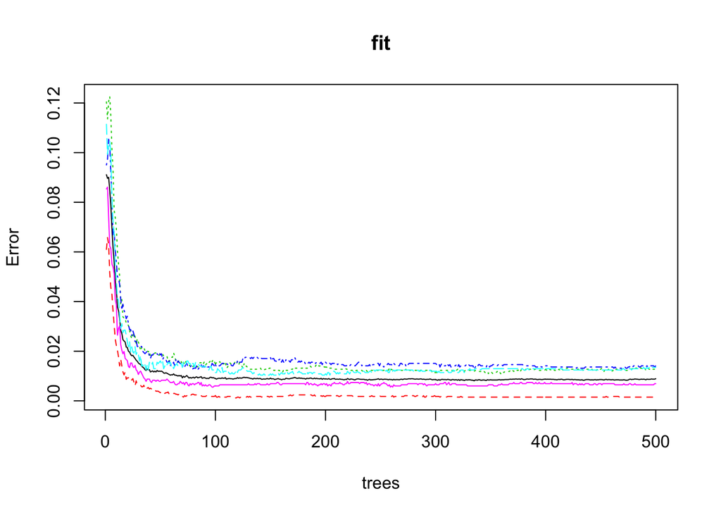

```r
plot (fit)
```

```r
imp = varImp (fit)
imp
```

```
##                      Overall
## roll_belt         1184.98424
## pitch_belt         664.87727
## yaw_belt           876.04683
## gyros_belt_x       126.47359
## gyros_belt_y       157.22140
## gyros_belt_z       348.56799
## roll_arm           328.88533
## pitch_arm          170.61394
## yaw_arm            320.83210
## gyros_arm_x        129.82550
## gyros_arm_y        145.29218
## gyros_arm_z         74.90312
## roll_dumbbell      492.98727
## pitch_dumbbell     264.46993
## yaw_dumbbell       330.94705
## gyros_dumbbell_x   142.90256
## gyros_dumbbell_y   322.83452
## gyros_dumbbell_z    93.18073
## magnet_dumbbell_z  700.79537
## roll_forearm       546.39488
## pitch_forearm      771.49432
## yaw_forearm        216.67365
## gyros_forearm_x     96.00044
## gyros_forearm_y    135.67157
## gyros_forearm_z     95.30065
## magnet_forearm_y   243.45499
## magnet_forearm_z   328.29754
```

Expected error rate of 0.8% sounds pretty good to me :-)

### Train the model in a slightly different way - fit2

Note this method takes a **loooong** time.

```r
fit2 = train (classe ~.,
              method="rf",
              data=myTraining,
              trControl=trainControl (method='cv'), number=5, allowParallel=TRUE )
fit2
```

```
## Random Forest
##
## 11776 samples
##    27 predictor
##     5 classes: 'A', 'B', 'C', 'D', 'E'
##
## No pre-processing
## Resampling: Cross-Validated (10 fold)
##
## Summary of sample sizes: 10598, 10598, 10598, 10599, 10599, 10599, ...
##
## Resampling results across tuning parameters:
##
##   mtry  Accuracy   Kappa      Accuracy SD  Kappa SD
##    2    0.9898956  0.9872175  0.002921488  0.003696799
##   14    0.9895553  0.9867884  0.002155995  0.002728546
##   27    0.9862440  0.9826019  0.001818795  0.002302239
##
## Accuracy was used to select the optimal model using  the largest value.
## The final value used for the model was mtry = 2.
```

```r
imp = varImp (fit2)
imp
```

```
## rf variable importance
##
##   only 20 most important variables shown (out of 27)
##
##                   Overall
## roll_belt          100.00
## yaw_belt            80.86
## magnet_dumbbell_z   64.30
## pitch_forearm       60.16
## pitch_belt          60.09
## roll_forearm        45.86
## roll_dumbbell       44.07
## roll_arm            32.96
## gyros_belt_z        30.69
## yaw_dumbbell        30.58
## gyros_dumbbell_y    29.29
## yaw_arm             28.61
## pitch_dumbbell      27.46
## magnet_forearm_z    27.13
## magnet_forearm_y    25.06
## yaw_forearm         19.57
## pitch_arm           14.54
## gyros_arm_x         13.14
## gyros_dumbbell_x    11.93
## gyros_arm_y         11.80
```

Note that this model was cross validated 10 fold.

### Check against the test set - both fit and fit2

```r
predictions = predict (fit, myTesting) #fit
confusionMatrix (predictions, myTesting$classe)
```

```
## Confusion Matrix and Statistics
##
##           Reference
## Prediction    A    B    C    D    E
##          A 2225    9    0    0    0
##          B    6 1501    6    1    1
##          C    0    8 1352   10    2
##          D    0    0   10 1271    3
##          E    1    0    0    4 1436
##
## Overall Statistics
##
##                Accuracy : 0.9922
##                  95% CI : (0.99, 0.994)
##     No Information Rate : 0.2845
##     P-Value [Acc > NIR] : < 2.2e-16
##
##                   Kappa : 0.9902
##  Mcnemar's Test P-Value : NA
##
## Statistics by Class:
##
##                      Class: A Class: B Class: C Class: D Class: E
## Sensitivity            0.9969   0.9888   0.9883   0.9883   0.9958
## Specificity            0.9984   0.9978   0.9969   0.9980   0.9992
## Pos Pred Value         0.9960   0.9908   0.9854   0.9899   0.9965
## Neg Pred Value         0.9988   0.9973   0.9975   0.9977   0.9991
## Prevalence             0.2845   0.1935   0.1744   0.1639   0.1838
## Detection Rate         0.2836   0.1913   0.1723   0.1620   0.1830
## Detection Prevalence   0.2847   0.1931   0.1749   0.1637   0.1837
## Balanced Accuracy      0.9976   0.9933   0.9926   0.9932   0.9975
```

```r
predictions = predict (fit2, myTesting) #fit2
confusionMatrix (predictions, myTesting$classe)
```

```
## Confusion Matrix and Statistics
##
##           Reference
## Prediction    A    B    C    D    E
##          A 2226   11    0    0    0
##          B    6 1499    4    0    0
##          C    0    8 1359   14    2
##          D    0    0    5 1268    3
##          E    0    0    0    4 1437
##
## Overall Statistics
##
##                Accuracy : 0.9927
##                  95% CI : (0.9906, 0.9945)
##     No Information Rate : 0.2845
##     P-Value [Acc > NIR] : < 2.2e-16
##
##                   Kappa : 0.9908
##  Mcnemar's Test P-Value : NA
##
## Statistics by Class:
##
##                      Class: A Class: B Class: C Class: D Class: E
## Sensitivity            0.9973   0.9875   0.9934   0.9860   0.9965
## Specificity            0.9980   0.9984   0.9963   0.9988   0.9994
## Pos Pred Value         0.9951   0.9934   0.9826   0.9937   0.9972
## Neg Pred Value         0.9989   0.9970   0.9986   0.9973   0.9992
## Prevalence             0.2845   0.1935   0.1744   0.1639   0.1838
## Detection Rate         0.2837   0.1911   0.1732   0.1616   0.1832
## Detection Prevalence   0.2851   0.1923   0.1763   0.1626   0.1837
## Balanced Accuracy      0.9977   0.9930   0.9949   0.9924   0.9980
```